# webscrapping2

#### Webscrapping FCA reviews

Import the get() function from the requests module. Assign the address of the web page to a variable named url. Request the server the content of the web page by using get(), and store the server’s response in the variable response. Print a small part of response's content by accessing its .text attribute (response is now a Response object).

```python
from requests import get
import numpy as np
import pandas as pd
from datetime import datetime
from dateutil.parser import parse
import re
import seaborn as sns
import matplotlib.pyplot as plt
import matplotlib.dates as mdates
%matplotlib inline

#url = 'https://www.glassdoor.com/Reviews/FCA-Fiat-Chrysler-Automobiles-Reviews-E149.htm'

#url="https://www.glassdoor.com/Reviews/FCA-Fiat-Chrysler-Automobiles-Auburn-Hills-Reviews-EI_IE149.0,29_IL.30,42_IC1134622.htm"


url="https://www.indeed.com/cmp/Fiat-Chrysler-Automobiles/reviews"

response = get(url)
print(response.text[:500])



from bs4 import BeautifulSoup

html_soup = BeautifulSoup(response.text, 'html.parser')
type(html_soup)


date_containers = html_soup.find_all('span', attrs={'class':'cmp-review-date-created'})
date_containers

text_containers = html_soup.find_all('span', attrs={'class':'cmp-review-text'})


text_containers[1].text


title_containers = html_soup.find_all('div', attrs={'class':'cmp-review-title'})

title_containers[1].text


location_containers = html_soup.find_all('span', attrs={'class':'cmp-reviewer-job-location'})

location_containers[1].text


job_containers = html_soup.find_all('span', attrs={'class':'cmp-reviewer'})



jobstatus_containers = html_soup.find_all('span', attrs={'class':'cmp-reviewer-job-title'})

jobstatus_containers[1].text[-21:-5]

job_containers[1].text
```

```
<!doctype html><html>
<head>
  <title>Working at Fiat Chrysler Automobiles: 1,793 Reviews | Indeed.com</title>
  <meta http-equiv="content-type" content="text/html;charset=UTF-8"/><meta name="description" content="1,793 reviews from Fiat Chrysler Automobiles employees about Fiat Chrysler Automobiles culture, salaries, benefits, work-life balance, management, job security, and more."/><meta name="viewport" co…
```

```
'Assembly Line Worker'
```

```python
date_containers[1].text
```

```
'June 6, 2018'
```

```python
len(date_containers)
```

```
21
```

```python
range(len(text_containers))
```

```
range(0, 21)
```

```python
date_container=[]
text_container=[]
title_container=[]
location_container=[]
job_container=[]
jobstatus_container=[]


for i in range(len(text_containers)):

    date_container.append(date_containers[i].text)
    text_container.append(text_containers[i].text)
    title_container.append(title_containers[i].text)
    location_container.append(location_containers[i].text)
    job_container.append(job_containers[i].text)
    jobstatus_container.append(jobstatus_containers[i].text[-21:-5])
```

```python
z=[len(date_container),len(text_container),len(title_container),len(location_container),
  len(job_container),len(jobstatus_container)]

df = pd.DataFrame({ 'Date' : date_container,
                       'Title' : title_container,
                        'Location' : location_container,
                        ' Job' :  job_container,
                        'Jobstatus' : jobstatus_container,
                       'Text' : text_container})

#Remove all parenthesis from Jobstatus column
df['Jobstatus']=df['Jobstatus'].str.replace("(","")

df.info()
```

```
<class 'pandas.core.frame.DataFrame'>
RangeIndex: 21 entries, 0 to 20
Data columns (total 6 columns):
 Job         21 non-null object
Date         21 non-null object
Jobstatus    21 non-null object
Location     21 non-null object
Text         21 non-null object
Title        21 non-null object
dtypes: object(6)
memory usage: 1.1+ KB
```

```python
#Adding the following lines to a new script will clear all variables each time you rerun the script:

#from IPython import get_ipython
#get_ipython().magic('reset -sf')

#len(pd.unique(u))
# Find the length of uique elements in a list
#len(set(w))
```

Create alist to store all website urls

```python
url="https://www.indeed.com/cmp/Fiat-Chrysler-Automobiles/reviews"
v='https://www.indeed.com/cmp/Fiat-Chrysler-Automobiles/reviews?start='

w=[]
for i in np.arange(20,1780,20):
    w.append(v+str(i))

url=[url]

url.append(w)

url.extend(w)
```

```python
url="https://www.indeed.com/cmp/Fiat-Chrysler-Automobiles/reviews"

def merge(l1, l2):
    yield from l1
    yield from l2

list(merge(url, w))
len(list(merge(url, set(w))))

len(set(url))
```

```
26
```

#### Function to extract information from the first page

```python
def webscrap (url):
    from requests import get
    import numpy as np
    import pandas as pd
    from bs4 import BeautifulSoup


    response = get(url)

    html_soup = BeautifulSoup(response.text, 'html.parser')

    date_containers = html_soup.find_all('span', attrs={'class':'cmp-review-date-created'})

    text_containers = html_soup.find_all('span', attrs={'class':'cmp-review-text'})


    title_containers = html_soup.find_all('div', attrs={'class':'cmp-review-title'})

    location_containers = html_soup.find_all('span', attrs={'class':'cmp-reviewer-job-location'})


    job_containers = html_soup.find_all('span', attrs={'class':'cmp-reviewer'})

    jobstatus_containers = html_soup.find_all('span', attrs={'class':'cmp-reviewer-job-title'})



    z=[len(date_containers),len(text_containers),len(title_containers),len(location_containers),
         len(job_containers),len(jobstatus_containers)]

       #min(z)
    z2=np.amin(z)



    date_container=[]
    text_container=[]
    title_container=[]
    location_container=[]
    job_container=[]
    jobstatus_container=[]


    for i in range(z2):

            date_container.append(date_containers[i].text)
            text_container.append(text_containers[i].text)
            title_container.append(title_containers[i].text)
            location_container.append(location_containers[i].text)
            job_container.append(job_containers[i].text)
            jobstatus_container.append(jobstatus_containers[i].text[-21:-5])



        # store extracted information in a dataframe
    df = pd.DataFrame({ 'Date' : date_container,
                       'Title' : title_container,
                        'Location' : location_container,
                        ' Job' :  job_container,
                        'Jobstatus' : jobstatus_container,
                       'Text' : text_container})

       #Remove all parenthesis from Jobstatus column
    df['Jobstatus']=df['Jobstatus'].str.replace("(","")


     # change the type of Date from object to  datetime column for plotting
    df['Date'] = pd.to_datetime(df['Date'])




    return df;
```

#### Repeat function over all webpages

```python
url="https://www.indeed.com/cmp/Fiat-Chrysler-Automobiles/reviews"

webscrap (url ).head(4)
```

|  | Job | Date | Jobstatus | Location | Text | Title |
| --- | --- | --- | --- | --- | --- | --- |
| 0 | Vehicle Maintenance Auditor (Contracted) | 2016-10-12 | Current Employee | Auburn Hills, MI 48326 | Top of line techs for FCA automobiles hard to ... | Productive good managment |
| 1 | Assembly Line Worker | 2018-06-06 | Current Employee | Belvidere, IL | Management is moving forward in positive direc... | Management |
| 2 | Assembly Line Worker | 2018-06-05 | Former Employee | Belvidere, IL | It was a fast pace environment. It was easy t... | It was a fast pace environment. |
| 3 | Facilitator Twinsburg Stamping Plant | 2018-06-05 | Former Employee | Twinsburg, OH | If you can find a plant that isn't in danger o... | Big 3 benefits |

#### Repeat function over all webpages

```python
pages_2last=list(map(webscrap,w))
```

#### Concatenate all pages extracted into one data frame

```python
page_1=webscrap(url)

#pd.concat([pages_2last,page_1])
AllData=pd.Series.append(page_1,pages_2last)

AllData=pd.DataFrame(AllData)
AllData.head()
```

|  | Job | Date | Jobstatus | Location | Text | Title |
| --- | --- | --- | --- | --- | --- | --- |
| 0 | Vehicle Maintenance Auditor (Contracted) | 2016-10-12 | Current Employee | Auburn Hills, MI 48326 | Top of line techs for FCA automobiles hard to ... | Productive good managment |
| 1 | Assembly Line Worker | 2018-06-06 | Current Employee | Belvidere, IL | Management is moving forward in positive direc... | Management |
| 2 | Assembly Line Worker | 2018-06-05 | Former Employee | Belvidere, IL | It was a fast pace environment. It was easy t... | It was a fast pace environment. |
| 3 | Facilitator Twinsburg Stamping Plant | 2018-06-05 | Former Employee | Twinsburg, OH | If you can find a plant that isn't in danger o... | Big 3 benefits |
| 4 | Warehouse Associate | 2018-06-05 | Former Employee | Tappan, NY | Chrystler was a great place to work for the ti... | Productive work place |

#### Write The File to excel

```python
# Create a Pandas dataframe from the data.
df = AllData

# Create a Pandas Excel writer using XlsxWriter as the engine.
writer = pd.ExcelWriter('/Users/nanaakwasiabayieboateng/PythonNLTK/AllData.xlsx', engine='xlsxwriter')

# Convert the dataframe to an XlsxWriter Excel object.
df.to_excel(writer, sheet_name='Sheet1')

# Close the Pandas Excel writer and output the Excel file.
writer.save()
```

#### Write to a csv File

```python
# Create a Pandas dataframe from the data.

pd.DataFrame.to_csv(AllData,'/Users/nanaakwasiabayieboateng/PythonNLTK/AllData.csv')
```

#### Natural Language Processing

```python
import spacy
nlp = spacy.load("en_core_web_sm")
AllData=pd.read_csv('/Users/nanaakwasiabayieboateng/PythonNLTK/AllData.csv')
```

Convert text to string and tokenize the strings into words.

```python
myvariable = AllData["Text"]
mystring = str(myvariable)
doc=nlp(mystring)

##alternatively try repr:

#mystring = repr(myvariable) # '4'
```

```python
doc.text.split()[0:10]
```

```
['0', 'Top', 'of', 'line', 'techs', 'for', 'FCA', 'automobiles', 'hard', 'to']
```

```python
len(doc.text.split())
```

```
598
```

```python
type(AllData)
```

```
pandas.core.frame.DataFrame
```

```python
AllData.dtypes
```

```
Unnamed: 0     int64
 Job          object
Date          object
Jobstatus     object
Location      object
Text          object
Title         object
dtype: object
```

```python
AllData.shape
```

```
(1869, 7)
```

#### Part-of-speech tagging, lemmatization

Tokenize,lemmatize,part of speech tag and check of the word is a stop word

```python
import spacy

nlp = spacy.load('en_core_web_sm')
doc = nlp( mystring)

for token in doc:
    print(token.text, token.lemma_, token.pos_, token.tag_, token.dep_,
          token.shape_, token.is_alpha, token.is_stop)
```

```
0 0 PUNCT NFP ROOT d False False
              SPACE _SP       False False
Top top NOUN NN ROOT Xxx True False
of of ADP IN prep xx True True
line line NOUN NN compound xxxx True False
techs tech NOUN NNS pobj xxxx True False
for for ADP IN prep xxx True True
FCA fca PROPN NNP compound XXX True False
automobiles automobile NOUN NNS pobj xxxx True False
hard hard ADJ JJ advmod xxxx True False
to to PART TO prep xx True True
... ... PUNCT : punct ... False False


 SPACE
 False False
1 1 NUM CD nummod d False False
              SPACE _SP       False False
Pros pros PROPN NNPS ROOT Xxxx True False
: : PUNCT : punct : False False
Benefits benefit NOUN NNS appos Xxxxx True False
, , PUNCT , punct , False False
flexible flexible ADJ JJ amod xxxx True False
overtime overtime NOUN NN appos xxxx True False
, , PUNCT , punct , False False
career career NOUN NN compound xxxx True False
advan advan NOUN NNS appos xxxx True False
... ... PUNCT : punct ... False False


 SPACE
 False False
2 2 NUM CD meta d False False
              SPACE _SP       False False
I -PRON- PRON PRP nsubj X True False
was be VERB VBD aux xxx True True
working work VERB VBG ROOT xxxx True False
as as ADP IN prep xx True True
supplier supplier NOUN NN amod xxxx True False
quality quality NOUN NN compound xxxx True False
```

[output cut: 950 more lines]

```


 SPACE
 False False
Name name NOUN NN ROOT Xxxx True False
: : PUNCT : punct : False False
Text text PROPN NNP nsubj Xxxx True False
, , PUNCT , punct , False False
Length length PROPN NNP npadvmod Xxxxx True False
: : PUNCT : punct : False False
1859 1859 NUM CD appos dddd False False
, , PUNCT , punct , False False
dtype dtype VERB VB appos xxxx True False
: : PUNCT : punct : False False
object object NOUN NN ROOT xxxx True False
```

#### Words Tokenization with Spacy

```python
tokenlist=[]
for token in doc:
    tokenlist.append(token)

len(tokenlist)
```

[output not shown]

#### Sentence Tokenization with Spacy

```python
sentences = list(doc.sents)
sentences[:5]
```

```
[0       ,
 Top of line techs for FCA automobiles hard to ...,
 1       Management is moving forward in positive direc...,
 2       ,
 It was a fast pace environment.  ]
```

#### Word Tokenization with nltk

```python
from nltk.tokenize import RegexpTokenizer

tokenizer = RegexpTokenizer(r'\w+')
tokenizer.tokenize(mystring)[:5]
```

```
['0', 'Top', 'of', 'line', 'techs']
```

#### Sentence Tokenization with nltk

```python
from nltk.tokenize import sent_tokenize, word_tokenize

sentences2=sent_tokenize(mystring)
print(sentences2[:2])
```

```
['0       Top of line techs for FCA automobiles hard to ...\n1       Management is moving forward in positive direc...\n2       It was a fast pace environment.', "It was easy t...\n3       If you can find a plant that isn't in danger o...\n4       Chrystler was a great place to work for the ti...\n5…
```

#### Remove Unwanted Characters from the Senences

- Matches any non-digit character; this is equivalent to the class [^0-9].
- Matches any alphanumeric character; this is equivalent to the class [a-zA-Z0-9_].
- Matches any non-alphanumeric character; this is equivalent to the class [^a-zA-Z0-9_].
- Matches any whitespace character; this is equivalent to the class [ \t\n\r\f\v].
- Matches any non-whitespace character; this is equivalent to the class [^ \t\n\r\f\v].

```python
import re

my_new_string = re.sub('[^ a-zA-Z]', '', sentences2[0])
print(my_new_string)
```

```
       Top of line techs for FCA automobiles hard to        Management is moving forward in positive direc       It was a fast pace environment
```

#### Check for Named Entities

```python
#for ent in doc.ents:
#    print(ent.text, ent.start_char, ent.end_char, ent.label_)



entlist=[]
ent_startlist=[]
ent_endlist=[]
ent_labellist=[]
for ent in doc.ents:
    entlist.append(ent.text)
    ent_startlist.append(ent.start_char)
    ent_endlist.append(ent.end_char)
    ent_labellist.append(ent.label_)

       # store extracted information in a dataframe
    Named_entity = pd.DataFrame({ 'Entity' : entlist,
                       'ent.start_char' : ent_startlist,
                        'ent.end_char' : ent_endlist,
                        ' ent.label_' :  ent_labellist
                       })

Named_entity.head()
```

|  | ent.label_ | Entity | ent.end_char | ent.start_char |
| --- | --- | --- | --- | --- |
| 0 | CARDINAL | 0 | 1 | 0 |
| 1 | ORG | FCA | 33 | 30 |
| 2 | GPE | \n | 58 | 57 |
| 3 | GPE | \n | 116 | 115 |
| 4 | GPE | \n | 174 | 173 |

#### Remove Stop Words nltk

```python
# Import nltk
import nltk

# Get English stopwords and print some of them
sw = nltk.corpus.stopwords.words('english')
```

```python
# split into words
from nltk.tokenize import word_tokenize
tokens = word_tokenize(mystring)

# convert to lower case
tokens = [w.lower() for w in tokens]

# remove punctuation from each word
import string
table = str.maketrans('', '', string.punctuation)
stripped = [w.translate(table) for w in tokens]


# remove remaining tokens that are not alphabetic
words = [word for word in stripped if word.isalpha()]


# filter out stop words
from nltk.corpus import stopwords
stop_words = set(stopwords.words('english'))
words = [w for w in words if not w in stop_words]
print(words[:10])



# split into words
from nltk.tokenize import word_tokenize
tokens = word_tokenize(mystring)

# stemming of words
from nltk.stem.porter import PorterStemmer
porter = PorterStemmer()
stemmed = [porter.stem(word) for word in tokens]
print(stemmed[:10])
```

```
['top', 'line', 'techs', 'fca', 'automobiles', 'hard', 'pros', 'benefits', 'flexible', 'overtime']
['0', 'top', 'of', 'line', 'tech', 'for', 'fca', 'automobil', 'hard', 'to']
```

#### Remove Stop Words with Spacy

```python
import spacy
nlp = spacy.load('en_core_web_sm')
# filter out stop words
from nltk.corpus import stopwords
stop_words = set(stopwords.words('english'))

words = [w for w in tokenlist if not w in stop_words]
print(words[:10])
```

```
[0,       , Top, of, line, techs, for, FCA, automobiles, hard]
```

#### Add Self Defined Stop Words

```python
from spacy.lang.en.stop_words import STOP_WORDS

#print(STOP_WORDS) # <- set of Spacy's default stop words

STOP_WORDS.add("add word")

for word in STOP_WORDS:
    lexeme = nlp.vocab[word]
    lexeme.is_stop = True
```

```python
from nltk.tokenize import sent_tokenize, word_tokenize
from nltk.corpus import stopwords

data = mystring
stopWords = set(stopwords.words('english'))
words = word_tokenize(data)
wordsFiltered = []

for w in words:
    if w not in stopWords:
        wordsFiltered.append(w)

    #print(wordsFiltered)
```

#### Remove all non alphabetic characters

```python
# remove all tokens that are not alphabetic
#The method isalnum() checks whether the string consists of alphanumeric characters.
cleanword = [word for word in wordsFiltered if word.isalpha()]
cleanword[:10]
```

```
['Top',
 'line',
 'techs',
 'FCA',
 'automobiles',
 'hard',
 'Pros',
 'Benefits',
 'flexible',
 'overtime']
```

#### Stemming Words

```python
from nltk.stem import PorterStemmer
from nltk.tokenize import sent_tokenize, word_tokenize

cleanwords = []
ps = PorterStemmer()

for word in cleanword:
    #print(ps.stem(word))
    cleanwords.append(ps.stem(word))
```

```python
cleanwords[:10]
```

```
['top',
 'line',
 'tech',
 'fca',
 'automobil',
 'hard',
 'pro',
 'benefit',
 'flexibl',
 'overtim']
```

#### Visualize Words with The Highest Frequency

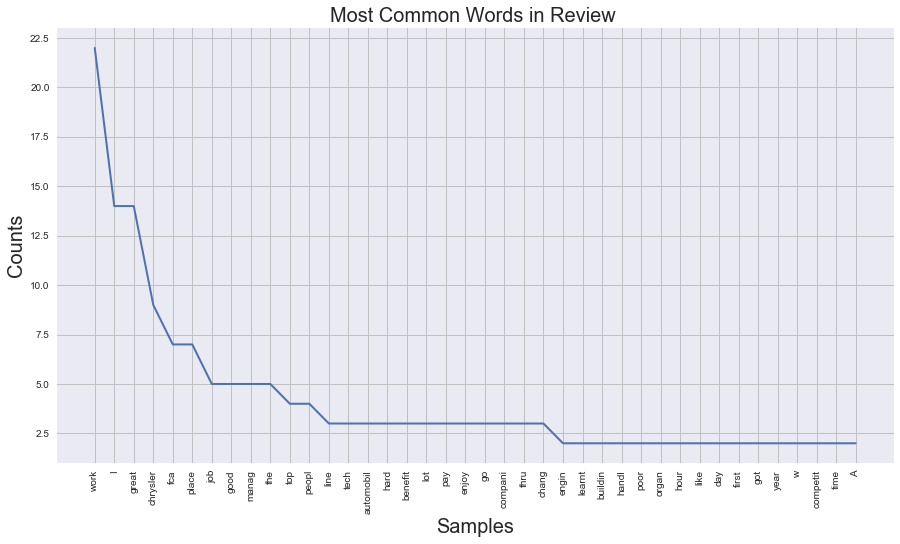

```python
#Import datavis libraries
import matplotlib.pyplot as plt
import seaborn as sns

# Figures inline and set visualization style
%matplotlib inline
sns.set()
#fig, ax = plt.subplots(1, 1,figsize=(10,7))
plt.figure(figsize=(15,8))
plt.plot( linewidth=2.0)
plt.title('Most Common Words in Review ', fontsize=20)
plt.ylabel('Counts', fontsize=20)
plt.xlabel('Words', fontsize=20)
# Create freq dist and plot
freqdist1 = nltk.FreqDist(cleanwords)
freqdist1.plot(40)


plt.show()
```

```python
from collections import Counter
c = Counter(cleanwords)
c.most_common(10)
```

```
[('work', 22),
 ('I', 14),
 ('great', 14),
 ('chrysler', 9),
 ('fca', 7),
 ('place', 7),
 ('job', 5),
 ('good', 5),
 ('manag', 5),
 ('the', 5)]
```

```python
#pd.DataFrame(c)
#df = pd.DataFrame(np.array(my_list).reshape(3,3), columns = list("abc"))
dfcommon = pd.DataFrame.from_dict(c, orient='index').reset_index()
dfcommon.columns = ['Word', 'Frequency']
dfcommon=dfcommon.sort_values(by='Frequency',ascending=[False])
dfcommon.head()
```

|  | Word | Frequency |
| --- | --- | --- |
| 13 | work | 22 |
| 12 | I | 14 |
| 28 | great | 14 |
| 83 | chrysler | 9 |
| 3 | fca | 7 |

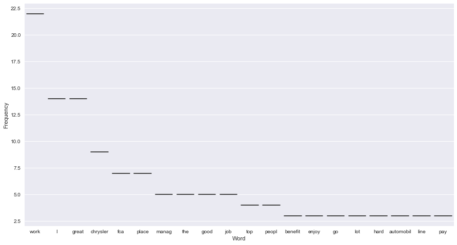

```python
boxdata=dfcommon.iloc[0:20,:]
plt.figure(figsize=(15,8))
ax = sns.boxplot(x="Word", y='Frequency', data=boxdata)
plt.show()
```

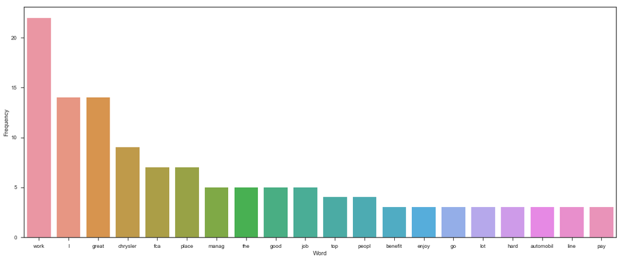

```python
plt.figure(figsize=(20,8))
sns.set_style('ticks')
#fig, ax = plt.subplots()
# the size of A4 paper
#fig.set_size_inches(11.7, 8.27)
ax = sns.barplot(x="Word", y="Frequency", data=boxdata)
plt.show()
```

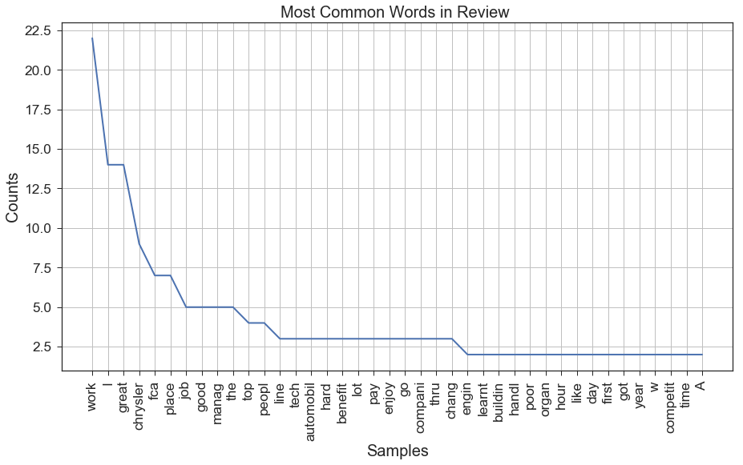

```python
params = {'legend.fontsize': 'x-large',
          'figure.figsize': (15, 8),
         'axes.labelsize': 'x-large',
         'axes.titlesize':'x-large',
         'xtick.labelsize':'x-large',
         'ytick.labelsize':'x-large'}
plt.rcParams.update(params)
plt.title('Most Common Words in Review ', fontsize=20)
plt.ylabel('Counts', fontsize=20)
plt.xlabel('Words', fontsize=20)
freqdist1 = nltk.FreqDist(cleanwords)
freqdist1.plot(40)
fig.savefig('fca.jpg')
plt.show()
```

```python
def ExtractAlphanumericc(InputString):
    import re
    #string = "man"
    pattern = re.compile('\W')
    string = re.sub(pattern, '', InputString)
    return string;
#print(string)


    ExtractAlphanumericc(mytring)
```

```python
def ExtractAlphanumeric(InputString):
    from string import ascii_letters, digits
    return "".join([ch for ch in InputString if ch in (ascii_letters + digits)])



#list(map( ExtractAlphanumeric,mystring))
```

```python
def ExtractAlphanumericc(InputString):
    import re
    #string = "man"
    pattern = re.compile('\W')
    string = re.sub(pattern, '', InputString)
    return string;
```

```python
 #ExtractAlphanumericc(mystring)

 #list(map( ExtractAlphanumericc,mystring))
```

```python
  #Remove all parenthesis from Jobstatus column
    #df['Jobstatus']=df['Jobstatus'].str.replace("(","")
import re
text = re.sub('[^A-Za-z]', ' ', str(words)) # Assuming it is a string
text
# remove all tokens that are not alphabetic
cleanwords = [word for word in words if word.isalpha()]
cleanwords[:10]
```

```
['Top',
 'of',
 'line',
 'techs',
 'for',
 'FCA',
 'automobiles',
 'hard',
 'to',
 'Pros']
```

#### Text Cleaning and Processing

```python
    #Convert to lower case
    mystring = mystring.lower()

    #Convert www.* or https?://* to URL
    mystring = re.sub('((www\.[^\s]+)|(https?://[^\s]+))','URL',mystring)

    #Convert @username to AT_USER
    mystring = re.sub('@[^\s]+','AT_USER',mystring)

    #Remove additional white spaces
    mystring = re.sub('[\s]+', ' ', mystring)

    #Replace #word with word
    mystring = re.sub(r'#([^\s]+)', r'\1', mystring)
    #replace ...
    mystring =re.sub('[...]', '', mystring)
    #trim
    mystring = mystring.strip('\'"')
    mystring[:100]
```

```
'0 top of line techs for fca automobiles hard to  1 pros:benefits, flexible overtime, career advan 2 '
```

#### Sentiment Analysis with VADER Library

```python
from vaderSentiment.vaderSentiment import SentimentIntensityAnalyzer

analyser = SentimentIntensityAnalyzer()
```

```python
import re

#remove ...\n characters
def removespecial (w):
    my_new_string = re.sub('[...]', '', w)
    #my_new_string = re.sub('[..\]', '', w)
    return my_new_string;

sentences3=list(map(removespecial,sentences2))
sentences3[0]
```

```
'0       Top of line techs for FCA automobiles hard to \n1       Pros:Benefits, flexible overtime, career advan\n2       I was working as supplier quality engineer'
```

```python
import re
my = re.sub('[...]', '', sentences2[0])
print(my)
```

```
0       Top of line techs for FCA automobiles hard to
1       Pros:Benefits, flexible overtime, career advan
2       I was working as supplier quality engineer
```

#### Text Polarity with VADER library

Define function to print sentiment scores

```python
def print_sentiment_scores(sentence):
    snt = analyser.polarity_scores(sentence)
    #print("{:-<40} {}".format(sentence, str(snt)))
    print("{:-<65} {}".format(sentence, str(snt)))
```

```python
print_sentiment_scores(sentences2[0])
```

```
0       Top of line techs for FCA automobiles hard to ...
1       Management is moving forward in positive direc...
2       It was a fast pace environment. {'neg': 0.054, 'neu': 0.736, 'pos': 0.209, 'compound': 0.6124}
```

The compound score is computed by summing the valence scores of each word in the lexicon, adjusted according to the rules, and then normalized to be between -1 (most extreme negative) and +1 (most extreme positive). This is the most useful metric if you want a single unidimensional measure of sentiment for a given sentence. Calling it a 'normalized, weighted composite score' is accurate.

It is also useful for researchers who would like to set standardized thresholds for classifying sentences as either positive, neutral, or negative. Typical threshold values (used in the literature cited on this page) are:

- positive sentiment: compound score >= 0.05
- neutral sentiment: (compound score > -0.05) and (compound score < 0.05)
- negative sentiment: compound score <= -0.05 The pos, neu, and neg scores are ratios for proportions of text that fall in each category (so these should all add up to be 1... or close to it with float operation). These are the most useful metrics if you want multidimensional measures of sentiment for a given sentence.

```python
analyzer.polarity_scores(sentences2[0])
```

```
{'compound': 0.6124, 'neg': 0.054, 'neu': 0.736, 'pos': 0.209}
```

```python
analyzer.polarity_scores(sentences2[0])["compound"]
```

```
0.6124
```

```python
from nltk.classify import NaiveBayesClassifier
from nltk.corpus import subjectivity
from nltk.sentiment import SentimentAnalyzer
from nltk.sentiment.util import *

sid = SentimentIntensityAnalyzer()
sid.polarity_scores(sentences2[0])


def nltkpolarity (w):
    sid = SentimentIntensityAnalyzer()
    compound=sid.polarity_scores(w)["compound"]

    return compound;


nltkpolarity(sentences2[0])


dnltk=list(map(nltkpolarity , AllData["Text"]))
dnltk[-1]
```

```
0.5574
```

#### Group Reviews into Positive, Neutral and Negative

```python
Reviewclass=[]

for i in dnltk:

        if i >= 0.05:
            Reviewclass.append("Positive")

        elif -0.05 < i < 0.05:
            Reviewclass.append("Neutral")

        else:
            Reviewclass.append("Negative")

Reviewclass[:5]
```

```
['Negative', 'Positive', 'Positive', 'Negative', 'Negative']
```

```python
dnltk[:5]
```

```
[-0.4215, 0.8481, 0.8755, -0.1531, -0.1531]
```

```python
Reviewclass=np.zeros(1869)

for i in range(len(dnltk)):

    if dnltk[i] >= 0.05:
            Reviewclass[i]=1
    elif -0.05 < dnltk[i] < 0.05:
            Reviewclass[i]=0
    else:
            Reviewclass[i]=-1

Reviewclass[:5]
```

```
array([-1.,  1.,  1., -1., -1.])
```

```python
#Reviewclass[Reviewclass=="Negative"]
AllData["Reviewclass"]=Reviewclass

AllData.head(4)
```

[output not shown]

```python
range(len(dnltk))
```

```
range(0, 1869)
```

#### Text Polarity and Subjectivity with Textblob

```python
from textblob import TextBlob
myvariable = AllData["Text"]
mystring = str(myvariable)


AllData.info()
```

[output not shown]

```python
AllData.dtypes
```

[output not shown]

```python
def textpolarity (w):
    zen = TextBlob(w)
    polarity=zen.sentiment.polarity
    subjectivity=zen.sentiment.subjectivity
    return polarity ,subjectivity;



d=list(map(textpolarity , AllData["Text"]))
len(d)
d[:5]

textpolarity(sentences2[0])
```

```
([0.15890151515151513], [0.546780303030303])
```

```python
df2 = pd.DataFrame(np.array(d).reshape(len(d),2), columns =['polarity','subjectivity'])


#df2.info()
AllData["polarity"]=df2["polarity"]

AllData["subjectivity"]=df2["subjectivity"]

# sort the date column
AllData=AllData.sort_values(by=['Date'], ascending=[ True])



# Create a Pandas dataframe from the data.

pd.DataFrame.to_csv(AllData,'/Users/nanaakwasiabayieboateng/PythonNLTK/AllData.csv')


AllData.head(2)
```

|  | Unnamed: 0 | Unnamed: 0.1 | Unnamed: 0.1.1 | Job | Date | Jobstatus | Location | Text | Title | polarity | subjectivity |
| --- | --- | --- | --- | --- | --- | --- | --- | --- | --- | --- | --- |
| 0 | 1868 | 1868 | 20 | Janitorial Facilities Supervisor | 2012-01-30 | Former Employee | Warren Truck Assembly Plant, Newark Assembly P... | Contracted thru Caravan Knight, Supervised all... | Contract Employee | 0.15 | 0.466667 |
| 1 | 1867 | 1867 | 19 | Materials Manager | 2012-02-02 | Former Employee | Multiple with 2 international assignments | Great to see how they are coming back. Buildin... | Solid company | 0.27 | 0.350000 |

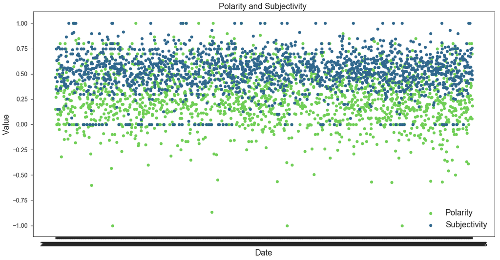

```python
# visualisation of anomaly throughout time (viz 1)
fig, ax = plt.subplots(1, 1,figsize=(20,10))
colors = {0:"#440154FF", 1:"#482878FF", 2:"#3E4A89FF", 3:"#31688EFF", 4:"#26828EFF", 5:"#1F9E89FF", 6:"#CFE11CFF", 7:"#482878FF", 8:"#482878FF", 9:"#B4DE2CFF", 10:"#FDE725FF", 11: "#9FDA3AFF", 12:"#71CF57FF", 13:"#4AC16DFF", 14: 'darkgrey'}



ax.scatter(AllData["Date"], AllData["polarity"], color="#71CF57FF", label='Polarity')
ax.scatter(AllData["Date"],AllData["subjectivity"], color="#31688EFF", label= 'Subjectivity')
plt.title('Polarity and Subjectivity ', fontsize=20)
plt.ylabel('Value', fontsize=20)
plt.xlabel('Date', fontsize=20)
plt.legend(fontsize=20,loc='lower right')
plt.show()
```

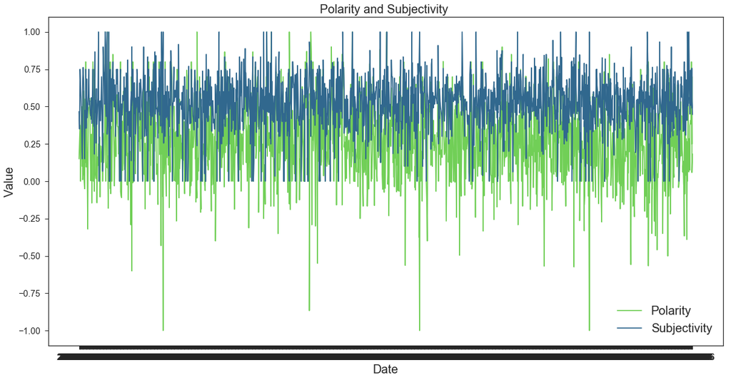

```python
# visualisation of anomaly throughout time (viz 1)
fig, ax = plt.subplots(1, 1,figsize=(20,10))
colors = {0:"#440154FF", 1:"#482878FF", 2:"#3E4A89FF", 3:"#31688EFF", 4:"#26828EFF", 5:"#1F9E89FF", 6:"#CFE11CFF", 7:"#482878FF", 8:"#482878FF", 9:"#B4DE2CFF", 10:"#FDE725FF", 11: "#9FDA3AFF", 12:"#71CF57FF", 13:"#4AC16DFF", 14: 'darkgrey'}

#AllData=AllData[:1000]

params = {'legend.fontsize': 'x-large',
          'figure.figsize': (15, 8),
         'axes.labelsize': 'x-large',
         'axes.titlesize':'x-large',
         'xtick.labelsize':'x-large',
         'ytick.labelsize':'x-large'}
plt.rcParams.update(params)

x=AllData["Date"]

ax.plot(x, AllData["polarity"], color="#71CF57FF", label='Polarity')
ax.plot(x,AllData["subjectivity"], color="#31688EFF", label= 'Subjectivity')
#set ticks every week
#ax.xaxis.set_major_locator(mdates.WeekdayLocator())
#set major ticks format
#ax.xaxis.set_major_formatter(mdates.DateFormatter('%b %d %y'))
plt.title('Polarity and Subjectivity ', fontsize=20)
plt.ylabel('Value', fontsize=20)
plt.xlabel('Date', fontsize=20)
#plt.xtick.labelsize(fontsize=20)
plt.legend(fontsize=20,loc='lower right')
plt.show()
```

[figure not shown]

```python
params = {'legend.fontsize': 'x-large',
          'figure.figsize': (15, 8),
         'axes.labelsize': 'x-large',
         'axes.titlesize':'x-large',
         'xtick.labelsize':'x-large',
         'ytick.labelsize':'x-large'}
plt.rcParams.update(params)
plt.title('Polarity and Subjectivity ', fontsize=20)
plt.ylabel('Values', fontsize=20)
plt.xlabel('Date', fontsize=20)
plt.plot(AllData['Date'], AllData['polarity'], 'k', AllData['Date'], AllData['subjectivity'],
         'r--',lw=2)
#fig.savefig('fca.jpg')
plt.grid(True)
plt.legend(loc='lower right')
plt.show()
```

```python
AllData.shape
```

[output not shown]

```python
import cufflinks as cf #cufflinks binds pandas to plotly for easy plotting
from plotly.offline import init_notebook_mode, iplot
# initialize notebook mode
init_notebook_mode(connected=True)
#type below in terminal before starting jupiter
# this stops an error message about limit of data that
# can be read into notebooks
#jupyter notebook --NotebookApp.iopub_data_rate_limit=10000000000
# set to offline
cf.go_offline()


#themes: solar,white,pearl,space,polar,henanigans


#reset the Date column to index
AllData2=AllData.set_index(['Date'])
AllData2

AllData2[['polarity', 'subjectivity']].iplot(kind='scatter', up_color='#482878FF', down_color='#1F9E89FF', theme='white',
                                           title='Polarity and Subjectivity', xTitle='Time',yTitle='Values')
```

[output not shown]

[interactive chart not shown]

```python
AllData2[['polarity', 'subjectivity']].iplot(kind='scatter',
                                           title='Polarity and Subjectivity', xTitle='Time',yTitle='Values')
```

[interactive chart not shown]

- average sentiment over day of the week
- average sentiment over weekend vs weekday
- average sentiment over year
- average sentiment over quarter of year
- topic modeling
- word cloud
- network analysis of words/Network Graph Visualization
- radar chart
- LSTM Model,naive bayes,svm

```python
series = AllData['Reviewclass'].value_counts()
series.iplot(kind='barh', xTitle='Frequency', title='Review Class')
```

[interactive chart not shown]

```python
# change the type of timestamp column for plotting
AllData['Date'] = pd.to_datetime(AllData['Date'])


# the day of the week (Monday=0, Sunday=6) and if it's a week end day or week day.
AllData['DayOfTheWeek'] = AllData['Date'].dt.dayofweek
AllData['Year'] = AllData['Date'].dt.year
AllData['Month'] = AllData['Date'].dt.month
AllData['Week'] = AllData['Date'].dt.week
AllData['Quarter'] = AllData['Date'].dt.quarter
```

```python
AllData.info()
```

[output not shown]

```python
AllData4=AllData.groupby('Year').mean()[['polarity','subjectivity']]


AllData4[['polarity', 'subjectivity']].iplot(kind='scatter', up_color='#482878FF', down_color='#1F9E89FF', theme='solar',
                                           title='Average Polarity and Subjectivity', xTitle='Year',yTitle='Values')
```

[interactive chart not shown]

```python
AllData5=AllData.groupby('DayOfTheWeek').mean()[['polarity','subjectivity']]


AllData5[['polarity', 'subjectivity']].iplot(kind='scatter', up_color='#482878FF', down_color='#1F9E89FF', theme='pearl',
                                           title='Average Polarity and Subjectivity', xTitle='Day of The Week',yTitle='Values')
```

[interactive chart not shown]

```python
AllData6=AllData.groupby('Month').mean()



AllData6[['polarity', 'subjectivity']].iplot(kind='scatter', theme='space',
                                           title='Average Polarity and Subjectivity', xTitle='Month ',yTitle='Values')
```

[interactive chart not shown]

```python
AllData7=AllData.groupby('Week').mean()



AllData7[['polarity', 'subjectivity']].iplot(kind='scatter', theme='henanigans',
                                           title='Average Polarity and Subjectivity', xTitle='Week ',yTitle='Values')
```

[interactive chart not shown]

```python
AllData7=AllData.groupby('Quarter').mean()



AllData7[['polarity', 'subjectivity']].iplot(kind='scatter', theme='white',
                                           title='Average Polarity and Subjectivity', xTitle='Quarter ',yTitle='Values')
```

[interactive chart not shown]

#### Sentiment Analysis through LSTMs

Sentiment Analysis: the process of computationally identifying and categorizing opinions expressed in a piece of text, especially in order to determine whether the writer's attitude towards a particular topic, product, etc. is positive, negative, or neutral.

```python
x = []
y = []
for value in lines:
    temp = value.split('\t')
    x.append(temp[0])
    temp[1].replace('\n','')
    y.append(int(temp[1]))




from keras.preprocessing.text import Tokenizer

tokenizer = Tokenizer(num_words=2500,split=' ')
tokenizer.fit_on_texts(x)




## CODE
tokenizer = Tokenizer()
texts = ["The sun is shining in June!","September is grey.","Life is beautiful in August.","I like it","This and other things?"]
tokenizer.fit_on_texts(texts)
print(tokenizer.word_index)
tokenizer.texts_to_sequences(["June is beautiful and I like it!"])


from keras.preprocessing.sequence import pad_sequences

X = tokenizer.texts_to_sequences(x)
X = pad_sequences(X)



import numpy as np
from sklearn.model_selection import train_test_split

Y = []
for val in y:
    if(val == 0):
        Y.append([1,0])
    else:
        Y.append([0,1])
Y = np.array(Y)

x_train, x_test, y_train, y_test = train_test_split(X,Y,train_size=0.8)



import keras
from keras.layers import Embedding, LSTM, Dense
from keras.models import Sequential

model = Sequential()
model.add(Embedding(2500,128,input_length=X.shape[1],dropout=0.2))
model.add(LSTM(300, dropout_U=0.2,dropout_W=0.2))
model.add(Dense(2,activation='softmax'))

model.compile(loss=keras.losses.categorical_crossentropy,optimizer='adam',metrics=['accuracy'])

model.fit(x_train,y_train,epochs=10,verbose=2,batch_size=32)

print(model.evaluate(x_test,y_test)[1])
```

[output not shown]

#### Generating Word Cloud

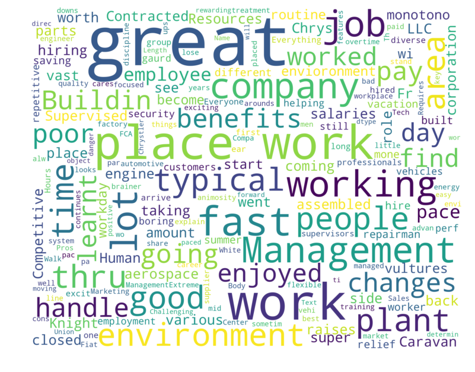

```python
import numpy as np # linear algebra
import pandas as pd # data processing, CSV file I/O (e.g. pd.read_csv)
from sklearn.model_selection import train_test_split # function for splitting data to train and test sets

import nltk
from nltk.corpus import stopwords
from nltk.classify import SklearnClassifier

from wordcloud import WordCloud,STOPWORDS
import matplotlib.pyplot as plt
%matplotlib inline


from subprocess import check_output
from os import path
from wordcloud import WordCloud

d = path.dirname("/Users/nanaakwasiabayieboateng/PythonNLTK")




# Read the whole text.
text = str(AllData['Text'])

stopwords = set(STOPWORDS)
stopwords.add("Chrysler")

color = ['black','white'];

#background_color="white", max_words=2000, mask=text,
#               stopwords=stopwords, contour_width=3, contour_color='steelblue'


wordcloud = WordCloud(stopwords=stopwords, max_words=2000,
                      #contour_color='steelblue',
                      #contour_width=3,
                      background_color=color[1],
                      width=2500,
                      height=2000,max_font_size=400
                     ).generate(text)
plt.figure(1,figsize=(13, 13))
plt.imshow(wordcloud, interpolation='bilinear')
plt.axis('off')
plt.show()

#print("Positive words")
#wordcloud_draw(train_pos,'white')
#print("Negative words")
#wordcloud_draw(train_neg)
```

We use NLTK’s Wordnet to find the meanings of words, synonyms, antonyms, and more. In addition, we use WordNetLemmatizer to get the root word.

```python
import nltk
nltk.download('wordnet')
from nltk.corpus import wordnet as wn
def get_lemma(word):
    lemma = wn.morphy(word)
    if lemma is None:
        return word
    else:
        return lemma

from nltk.stem.wordnet import WordNetLemmatizer
def get_lemma2(word):
    return WordNetLemmatizer().lemmatize(word)
```